# Machine Learning at the service of the vineyard

##### PAM

We also conducted a PAM analysis for our data sets and also compared between the balanced and unbalanced full set. We will take the Red wine data set for this analysis

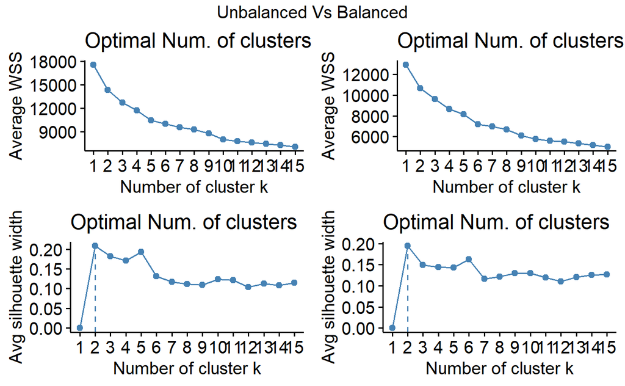

Also no major difference but it seems the balanced dataset hints more at lower number of clusters compared to the unbalanced full set.

Let us visualize using the Silhouette plot to check the effect of cluster number on our data classification.

Using 4 clusters we try to see if there is any difference in our 2 sets.

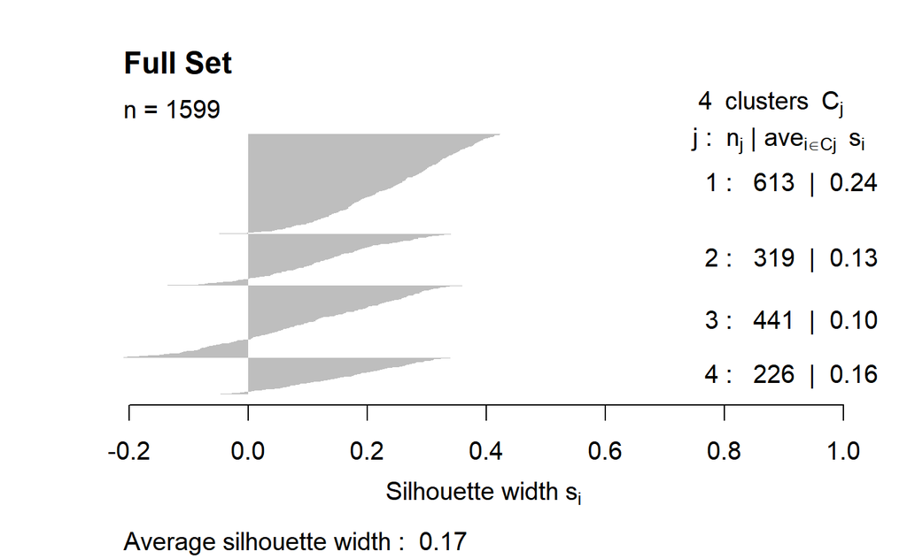

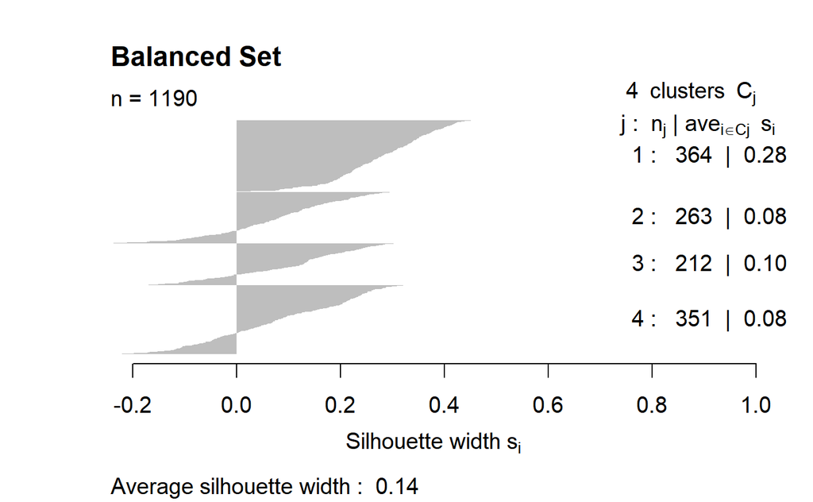

*Note* the Full set has slightly larger width, but has overall fewer misclasifications compared to our balanced dataset

### Principal Component Analysis

We have created summary graphs, fully comprehensive, for PCA testing one for each of the Full data set and the balanced training set for both Red and white wine.

Here are the results:

**Red Wine**

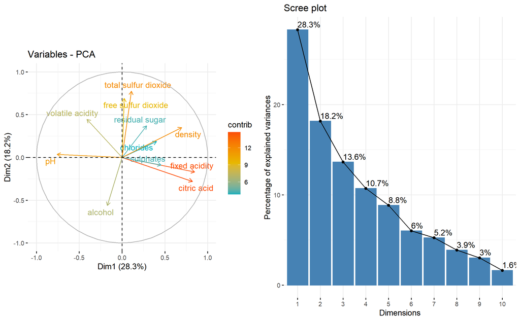

Two principal components already represent 50% of the variance. Taking 3 more would bring that close to 80%, which is a significant dimension reduction.

The first dimension is positively correlated with fixed acidity and citric acid, and negatively with pH (which is un-suprising, since high acidity means a low pH in general). Conversely, the second PC seems to represent levels of sulfur dioxides, while being negatively correlated with alcohol.

**White Wine**

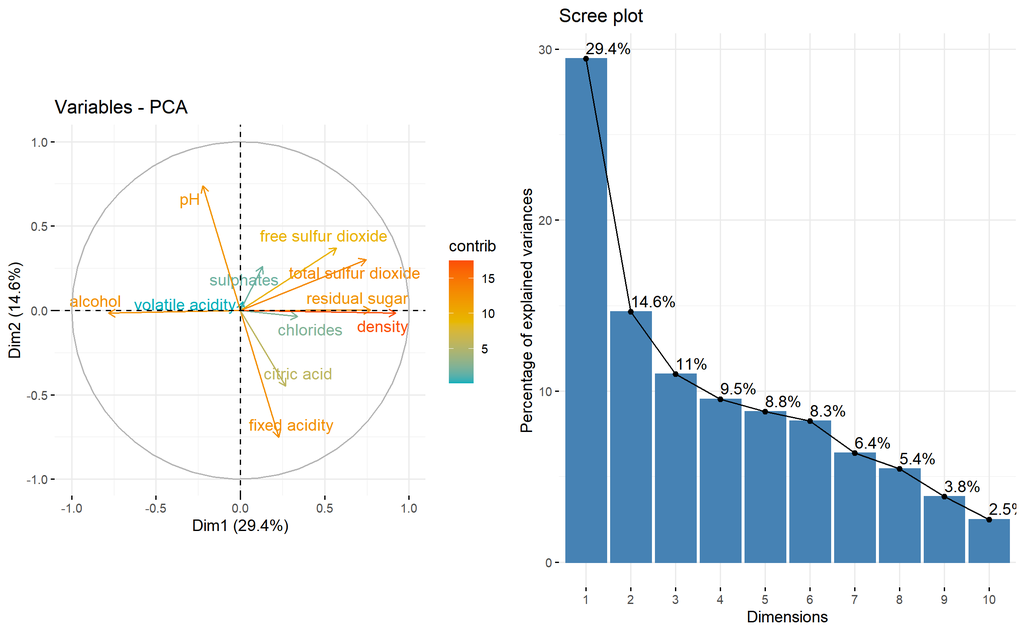

For white wine, the first two PC also represent nearly 50% of variance. However, they seem flipped compared to red wine, with acidity (hence, pH also) having less variance than sulfur dioxides, residual sugar (logically negatively correlated with alcohol), and density.

Although we performed these analyses on the balanced sets, the full sets showed very similar results, while needing more computational power (since they are larger), hence the reason why we show only balanced sets analysis.

For white wine, although the order of variables are different than for red wines, we also see no significant difference between our balanced set and our full set.

Taken together, this seems to suggest that using our balanced sets (which are smaller than our full set) yields a good picture of the full sets. This could be used to reduce computational needs for further analysis.

#### Factor Analysis

Performing factor analysis on both white and red wines show strikingly similar results to PCA, confirming the previous results.

**Fullset - Red Wine**

```
#> $loadings
#>
#> Loadings:
#>                      Factor1 Factor2 Factor3 Factor4 Factor5 Factor6
#> fixed acidity         1.00
#> citric acid           0.53           -0.32
#> pH                   -0.79
#> free sulfur dioxide           0.67
#> total sulfur dioxide          1.01
#> volatile acidity                      1.10
#> alcohol                                       1.00
#> chlorides                                             0.92
#> residual sugar                                                0.50
#> density               0.31                                    0.83
#> sulphates                                             0.45
#>
#>                Factor1 Factor2 Factor3 Factor4 Factor5 Factor6
#> SS loadings       2.06    1.52    1.39    1.21    1.13    1.10
#> Proportion Var    0.19    0.14    0.13    0.11    0.10    0.10
#> Cumulative Var    0.19    0.33    0.45    0.56    0.66    0.76
```

**Balanced Set - White Wine**

```
#> $loadings
#>
#> Loadings:
#>                      Factor1 Factor2 Factor3 Factor4 Factor5 Factor6
#> residual sugar        0.82                   -0.43    0.35
#> total sulfur dioxide  0.69                    0.63
#> density               0.97
#> alcohol              -0.81                            0.56
#> fixed acidity                 0.80   -0.55
#> volatile acidity              0.55    0.82
#> pH                           -0.34                            0.66
#> citric acid
#> chlorides
#> free sulfur dioxide   0.43                    0.38
#> sulphates                                                     0.31
#>
#>                Factor1 Factor2 Factor3 Factor4 Factor5 Factor6
#> SS loadings       3.11    1.15    1.14    0.82    0.67    0.59
#> Proportion Var    0.28    0.10    0.10    0.07    0.06    0.05
#> Cumulative Var    0.28    0.39    0.49    0.57    0.63    0.68
```

*Notes One thing we can spot is that the different predicting variables do not have the same representation and importance equally for both Red and White dataset, the PCA plots and dimensions show some differences, hence why we proceed with checking Variable Important*

# Variable Importance

Although Variable Importance is an important cornerstone of Machine Learning and should be conducted as analysis at the beginning of modeling to decide whether to add or drop independent variables from your predictive models, but we have still decided to include a small analysis on our Wine datasets to check whether the same variables are important for both Red and white wine quality prediction using different models.

We use a training control of Repeated Cross-Validation with 3 repeats of 5 Validations and conducted the following model trainings: -Logisitic regression with stepwise AIC -KNN -SVM (we use our already trained optimised models) -Classification tree (both categorical and numerical) -Linear Regression

The trainings were all made on our balanced datasets.

**RED Wine**

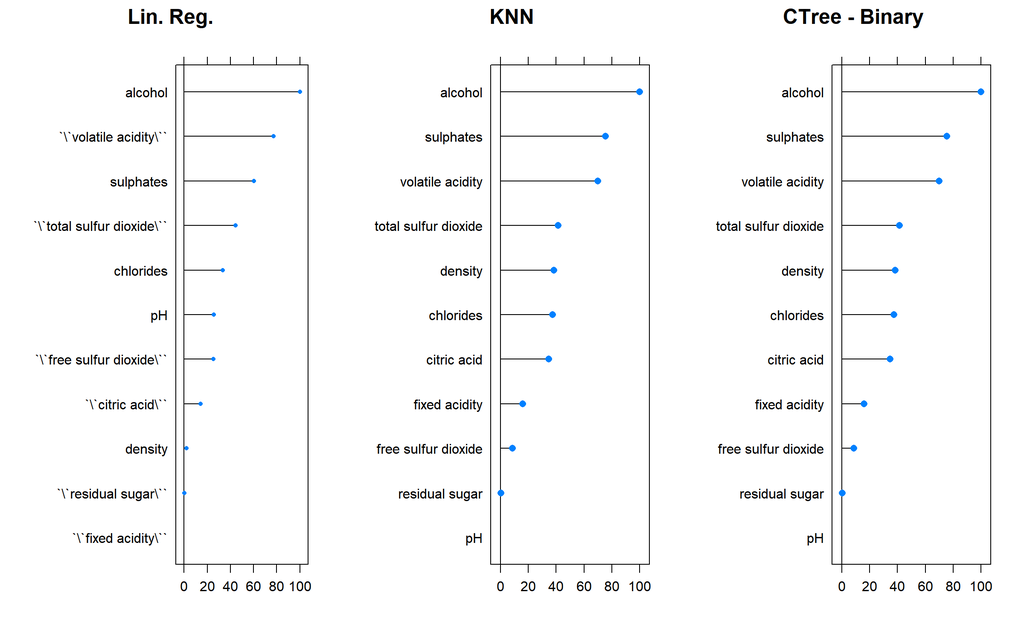

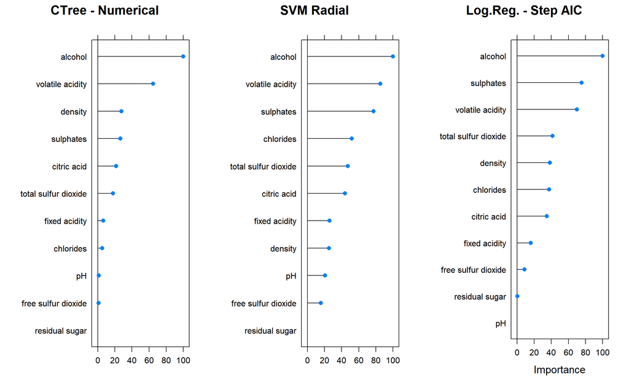

All the models agree on the importance of Alcohol, Sulphate and Volatile acidity and that pH, residual sugar and free sulfur are of very low importance in their predictions

**WHITE WINE**

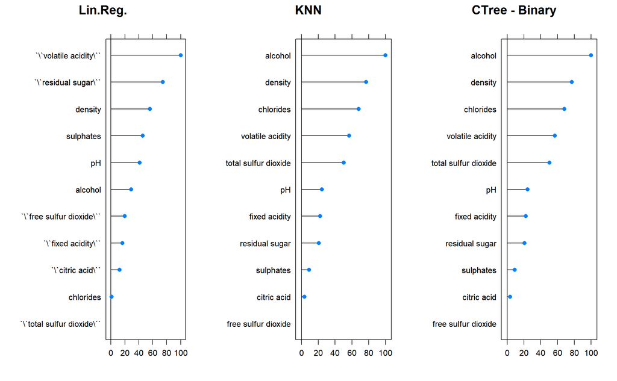

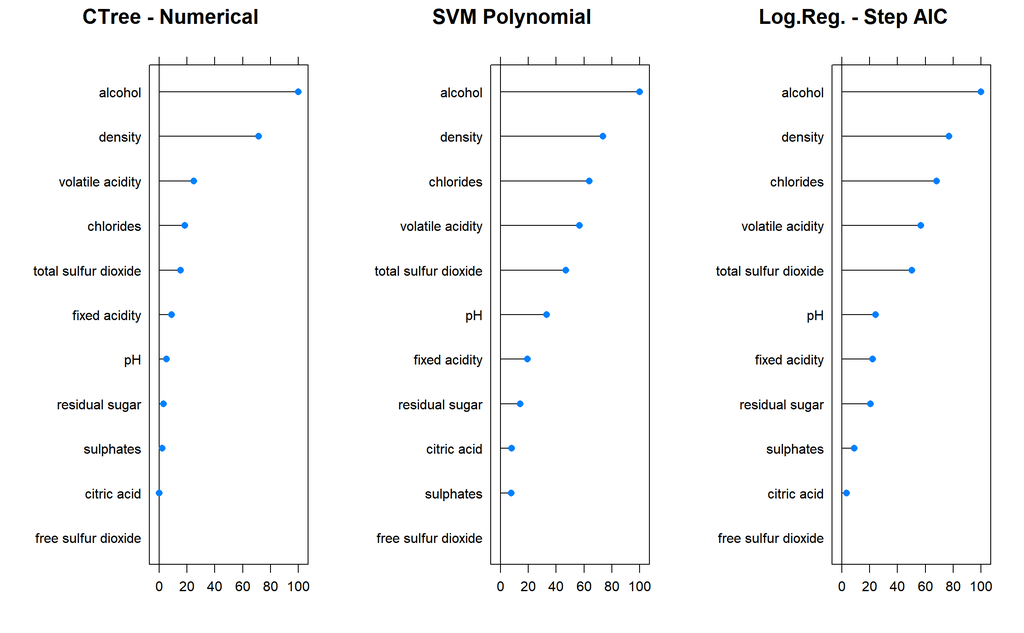

Unlike the Red wine dataset, Density jumps as an important factor along with alcohol and chlorides. On the other hand free sulfur, citric acid, and surprisingly sulphates, are of very low importance.

Another important note is that the Linear regression model seems to be a bit alienated from the rest in both Red and White wine datasets. As it is the simplest, and most “crude” model, we believe that we can safely disregard that model.

# Results and Conclusion

To summarize all these lengthy analyses, here is a table containing most of the interesting metrics for each model that we performed:

### Red Wine

**Red Wine**

| Method | Accuracy | Balanced Accuracy | Kappa | Sensitivity | Specificity |
| --- | --- | --- | --- | --- | --- |
| Bootstrapping | 0.759 | 0.760 | 0.518 | 0.768 | 0.751 |
| Cross-validation | 0.759 | 0.760 | 0.518 | 0.768 | 0.751 |
| GLM | 0.759 | 0.760 | 0.518 | 0.768 | 0.751 |
| K-NN | 0.819 | 0.816 | 0.635 | 0.775 | 0.858 |
| Naive-Bayes | 0.753 | 0.754 | 0.506 | 0.762 | 0.746 |
| Naive-Bayes (with priors) | 0.747 | 0.745 | 0.491 | 0.715 | 0.775 |
| SVM linear | 0.738 | 0.740 | 0.477 | 0.781 | 0.698 |
| SVM polynomial | 0.781 | 0.787 | 0.567 | 0.894 | 0.680 |
| SVM radial | 0.809 | 0.812 | 0.620 | 0.861 | 0.763 |
| SVM radial-tuned | 0.806 | 0.810 | 0.614 | 0.868 | 0.751 |
| Tree | 0.759 | 0.757 | 0.515 | 0.709 | 0.805 |
| KNN-ROCtune | 0.875 | 0.880 | 0.752 | 0.974 | 0.787 |
| NB-ROCtune | 0.759 | 0.765 | 0.523 | 0.861 | 0.669 |
| GLM-ROCtune | 0.762 | 0.762 | 0.524 | 0.762 | 0.763 |
| Tree-ROCtune | 0.775 | 0.777 | 0.551 | 0.808 | 0.746 |
| Tree-R.F. | 0.959 | 0.959 | 0.919 | 0.942 | 0.976 |
| Tree-Ranger | 0.963 | 0.962 | 0.925 | 0.948 | 0.976 |

### White Wine

White Wine

| Method | Accuracy | Balanced Accuracy | Kappa | Sensitivity | Specificity |
| --- | --- | --- | --- | --- | --- |
| Bootstrapping | 0.731 | 0.743 | 0.443 | 0.779 | 0.707 |
| Cross-validation | 0.731 | 0.743 | 0.443 | 0.779 | 0.707 |
| GLM | 0.731 | 0.743 | 0.443 | 0.779 | 0.707 |
| K-NN | 0.777 | 0.794 | 0.537 | 0.844 | 0.744 |
| Naive-Bayes | 0.688 | 0.691 | 0.350 | 0.701 | 0.681 |
| Naive-Bayes (with priors) | 0.700 | 0.671 | 0.335 | 0.589 | 0.754 |
| SVM linear | 0.726 | 0.750 | 0.446 | 0.822 | 0.678 |
| SVM polynomial | 0.759 | 0.758 | 0.485 | 0.754 | 0.762 |
| SVM radial | 0.781 | 0.795 | 0.543 | 0.838 | 0.753 |
| SVM poly-tuned | 0.818 | 0.839 | 0.622 | 0.897 | 0.780 |
| Tree | 0.734 | 0.729 | 0.431 | 0.717 | 0.742 |
| KNN-ROCtune | 0.751 | 0.725 | 0.444 | 0.651 | 0.800 |
| NB-ROCtune | 0.679 | 0.699 | 0.353 | 0.757 | 0.640 |
| GLM-ROCtune | 0.731 | 0.743 | 0.443 | 0.779 | 0.707 |
| Tree-ROCtune | 0.737 | 0.734 | 0.439 | 0.726 | 0.742 |
| Tree-W.F. | 0.916 | 0.898 | 0.819 | 0.814 | 0.982 |
| Tree-Ranger | 0.913 | 0.894 | 0.812 | 0.811 | 0.978 |

#### Remarks

*Supervised Learning*

*Unsupervised Learning*

#### Limitations

*Forward Note*

It would be very interesting to see whether we can get a larger data set with scores that are continuous in nature (eg 0 to 100) and try to check the difference in accuracy in supervised models between a balanced and non-balanced one.

Another interesting topic would be to try to predict alcohol levels for example or acidity levels in a certain wine given the other factors.

Moreover, the dataset used only “intrinsic” variables, whereas other variables such as the price of a bottle probably play a big role in wine appreciation, depending on the tasting and scoring process (blind or not, at home or at the vinyard, etc.).

Finally, a multi-class model could be used to try to classify non-binary outcomes of quality, price and other factors.